# Random Forest

# Tarea 5.

# Metodos supervisados

Librerias

```r
library(caTools)
library(rpart)
library(rpart.plot)
library(dplyr)
library(randomForest)
library(ggplot2)
library(visdat)
```

1. Análisis del Problema

Este conjunto de datos incluye descripciones de muestras hipotéticas correspondientes a 23 especies de hongos branquiales en el hongo de la familia Agaricus y Lepiota extraídas de la Guía de campo de la Sociedad Audubon de hongos de América del Norte (1981). Cada especie clasificada en dos grupos las definitivamente comestibles o las de comestibilidad desconocida (no se recomiendan) junto con las definitivamente venenosas. La Guía establece claramente que no existe una regla simple para determinar la comestibilidad de un hongo; ninguna regla como “leaves of three, let it be” para el roble venenoso y la hiedra venenosa.

Fuente del dataset: https://archive.ics.uci.edu/ml/machine-learning-databases/mushroom/agaricus-lepiota.data

1. Cargue el archivo agaricus_lepiota.data.csv en una variable

```r
colnames <- c("class", "cap-shape", "cap-surface", "cap-color", "bruises", "odor", "gill-attachment", "gill-spacing", "gill-size", "gill-color", "stalk-shape", "stalk-root", "stalk-surface-above-ring", "stalk-surface-below-ring", "stalk-color-above-ring", "stalk-color-below-ring", "veil-type", "veil-color", "ring-number", "ring-type", "spore-print-color", "population", "habitat")
data <- read.csv('agaricuslepiota.data', header = F, col.names =  colnames, strip.white = T)
```

2. Desarolle el Entendimiento de los Datos

Para analizar este problema, se tiene un conjunto de datos con 8124 observaciones y 22 variables nominales: 1. cap-shape: bell=b,conical=c,convex=x,flat=f,knobbed=k,sunken=s 2. cap-surface: fibrous=f,grooves=g,scaly=y,smooth=s 3. cap-color: brown=n,buff=b,cinnamon=c,gray=g,green=r, pink=p,purple=u,red=e,white=w,yellow=y 4. bruises?: bruises=t,no=f 5. odor: almond=a,anise=l,creosote=c,fishy=y,foul=f, musty=m,none=n,pungent=p,spicy=s 6. gill-attachment: attached=a,descending=d,free=f,notched=n 7. gill-spacing: close=c,crowded=w,distant=d 8. gill-size: broad=b,narrow=n 9. gill-color: black=k,brown=n,buff=b,chocolate=h,gray=g, green=r,orange=o,pink=p,purple=u,red=e, white=w,yellow=y 10. stalk-shape: enlarging=e,tapering=t 11. stalk-root: bulbous=b,club=c,cup=u,equal=e, rhizomorphs=z,rooted=r,missing=? 12. stalk-surface-above-ring: fibrous=f,scaly=y,silky=k,smooth=s 13. stalk-surface-below-ring: fibrous=f,scaly=y,silky=k,smooth=s 14. stalk-color-above-ring: brown=n,buff=b,cinnamon=c,gray=g,orange=o, pink=p,red=e,white=w,yellow=y 15. stalk-color-below-ring: brown=n,buff=b,cinnamon=c,gray=g,orange=o, pink=p,red=e,white=w,yellow=y 16. veil-type: partial=p,universal=u 17. veil-color: brown=n,orange=o,white=w,yellow=y 18. ring-number: none=n,one=o,two=t 19. ring-type: cobwebby=c,evanescent=e,flaring=f,large=l, none=n,pendant=p,sheathing=s,zone=z 20. spore-print-color: black=k,brown=n,buff=b,chocolate=h,green=r, orange=o,purple=u,white=w,yellow=y 21. population: abundant=a,clustered=c,numerous=n, scattered=s,several=v,solitary=y 22. habitat: grasses=g,leaves=l,meadows=m,paths=p, urban=u,waste=w,woods=d

```r
glimpse(data)
```

```
## Observations: 8,124
## Variables: 23
## $ class                    <fct> p, e, e, p, e, e, e, e, p, e, e, e, e...
## $ cap.shape                <fct> x, x, b, x, x, x, b, b, x, b, x, x, b...
## $ cap.surface              <fct> s, s, s, y, s, y, s, y, y, s, y, y, s...
## $ cap.color                <fct> n, y, w, w, g, y, w, w, w, y, y, y, y...
## $ bruises                  <fct> t, t, t, t, f, t, t, t, t, t, t, t, t...
## $ odor                     <fct> p, a, l, p, n, a, a, l, p, a, l, a, a...
## $ gill.attachment          <fct> f, f, f, f, f, f, f, f, f, f, f, f, f...
## $ gill.spacing             <fct> c, c, c, c, w, c, c, c, c, c, c, c, c...
## $ gill.size                <fct> n, b, b, n, b, b, b, b, n, b, b, b, b...
## $ gill.color               <fct> k, k, n, n, k, n, g, n, p, g, g, n, w...
## $ stalk.shape              <fct> e, e, e, e, t, e, e, e, e, e, e, e, e...
## $ stalk.root               <fct> e, c, c, e, e, c, c, c, e, c, c, c, c...
## $ stalk.surface.above.ring <fct> s, s, s, s, s, s, s, s, s, s, s, s, s...
## $ stalk.surface.below.ring <fct> s, s, s, s, s, s, s, s, s, s, s, s, s...
## $ stalk.color.above.ring   <fct> w, w, w, w, w, w, w, w, w, w, w, w, w...
## $ stalk.color.below.ring   <fct> w, w, w, w, w, w, w, w, w, w, w, w, w...
## $ veil.type                <fct> p, p, p, p, p, p, p, p, p, p, p, p, p...
## $ veil.color               <fct> w, w, w, w, w, w, w, w, w, w, w, w, w...
## $ ring.number              <fct> o, o, o, o, o, o, o, o, o, o, o, o, o...
## $ ring.type                <fct> p, p, p, p, e, p, p, p, p, p, p, p, p...
## $ spore.print.color        <fct> k, n, n, k, n, k, k, n, k, k, n, k, n...
## $ population               <fct> s, n, n, s, a, n, n, s, v, s, n, s, s...
## $ habitat                  <fct> u, g, m, u, g, g, m, m, g, m, g, m, g...
```

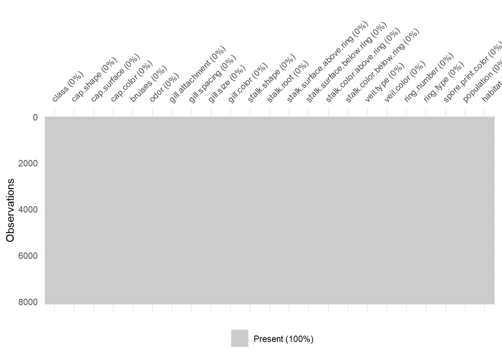

```r
vis_miss(data)
```

```r
summary(data)
```

```
##  class    cap.shape cap.surface   cap.color    bruises       odor
##  e:4208   b: 452    f:2320      n      :2284   f:4748   n      :3528
##  p:3916   c:   4    g:   4      g      :1840   t:3376   f      :2160
##           f:3152    s:2556      e      :1500            s      : 576
##           k: 828    y:3244      y      :1072            y      : 576
##           s:  32                w      :1040            a      : 400
##           x:3656                b      : 168            l      : 400
##                                 (Other): 220            (Other): 484
##  gill.attachment gill.spacing gill.size   gill.color   stalk.shape
##  a: 210          c:6812       b:5612    b      :1728   e:3516
##  f:7914          w:1312       n:2512    p      :1492   t:4608
##                                         w      :1202
##                                         n      :1048
##                                         g      : 752
##                                         h      : 732
##                                         (Other):1170
##  stalk.root stalk.surface.above.ring stalk.surface.below.ring
##  ?:2480     f: 552                   f: 600
##  b:3776     k:2372                   k:2304
##  c: 556     s:5176                   s:4936
##  e:1120     y:  24                   y: 284
##  r: 192
##
##
##  stalk.color.above.ring stalk.color.below.ring veil.type veil.color
##  w      :4464           w      :4384           p:8124    n:  96
##  p      :1872           p      :1872                     o:  96
##  g      : 576           g      : 576                     w:7924
##  n      : 448           n      : 512                     y:   8
##  b      : 432           b      : 432
##  o      : 192           o      : 192
##  (Other): 140           (Other): 156
##  ring.number ring.type spore.print.color population habitat
##  n:  36      e:2776    w      :2388      a: 384     d:3148
##  o:7488      f:  48    n      :1968      c: 340     g:2148
##  t: 600      l:1296    k      :1872      n: 400     l: 832
##              n:  36    h      :1632      s:1248     m: 292
##              p:3968    r      :  72      v:4040     p:1144
##                        b      :  48      y:1712     u: 368
##                        (Other): 144                 w: 192
```

```r
# Actualizar el ? para tener datos un poco mas claros
levels(data$stalk.root) <- c("missing","bulbous","club","equal","rooted")
```

3. Utilizando barplot cree un gráfico de los atributos del dataset, observe las correlaciones entre atributos

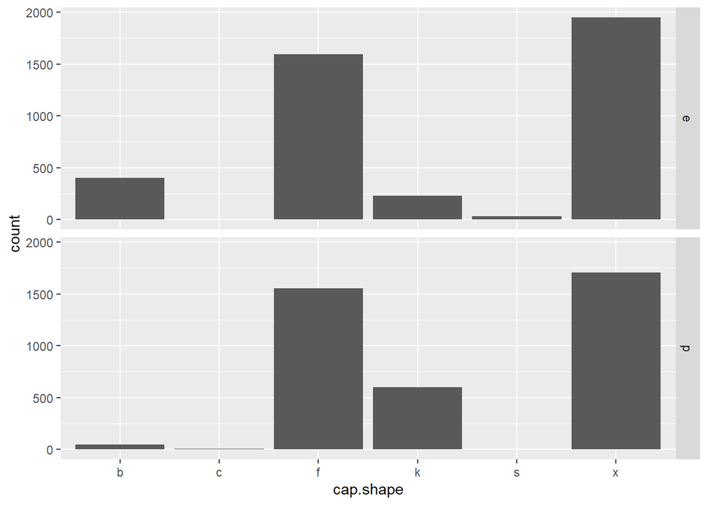

```r
ggplot(data, aes(x = cap.shape)) + geom_histogram(stat = "count") + facet_grid(c("class"))
```

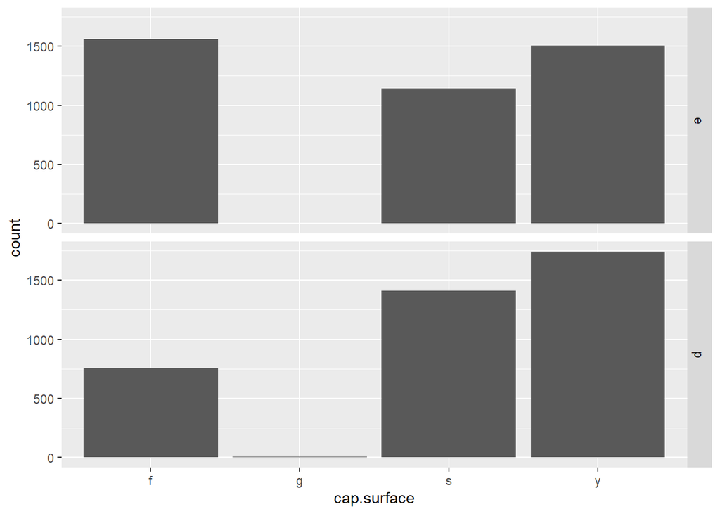

```r
ggplot(data, aes(x = cap.surface)) + geom_histogram(stat = "count") + facet_grid(c("class"))
```

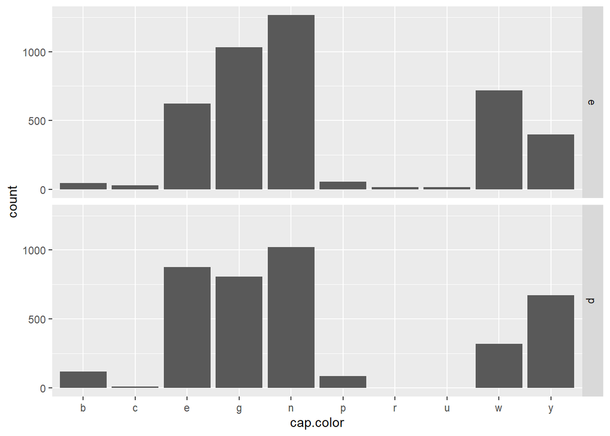

```r
ggplot(data, aes(x = cap.color)) + geom_histogram(stat = "count") + facet_grid(c("class"))
```

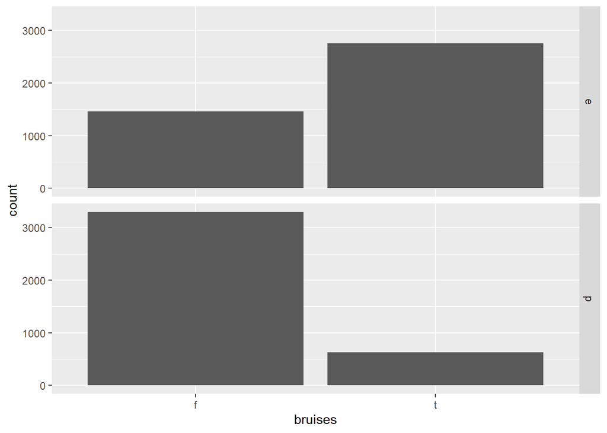

```r
ggplot(data, aes(x = bruises)) + geom_histogram(stat = "count") + facet_grid(c("class"))
```

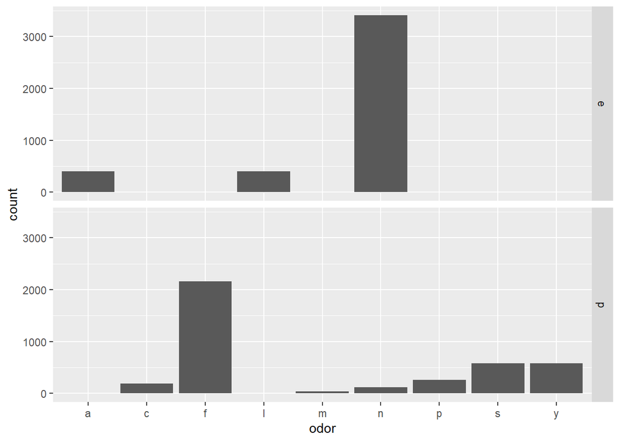

```r
ggplot(data, aes(x = odor)) + geom_histogram(stat = "count") + facet_grid(c("class"))
```

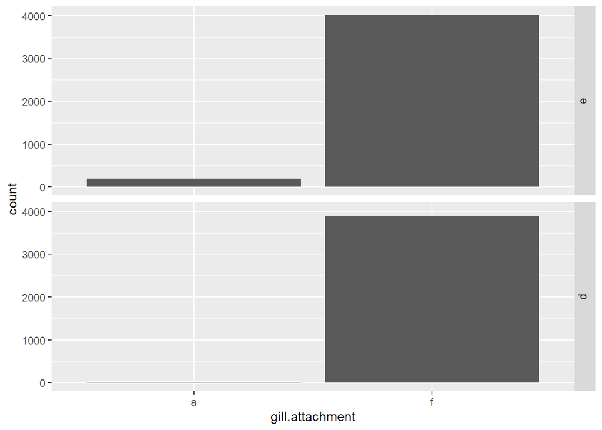

```r
ggplot(data, aes(x = gill.attachment)) + geom_histogram(stat = "count") + facet_grid(c("class"))
```

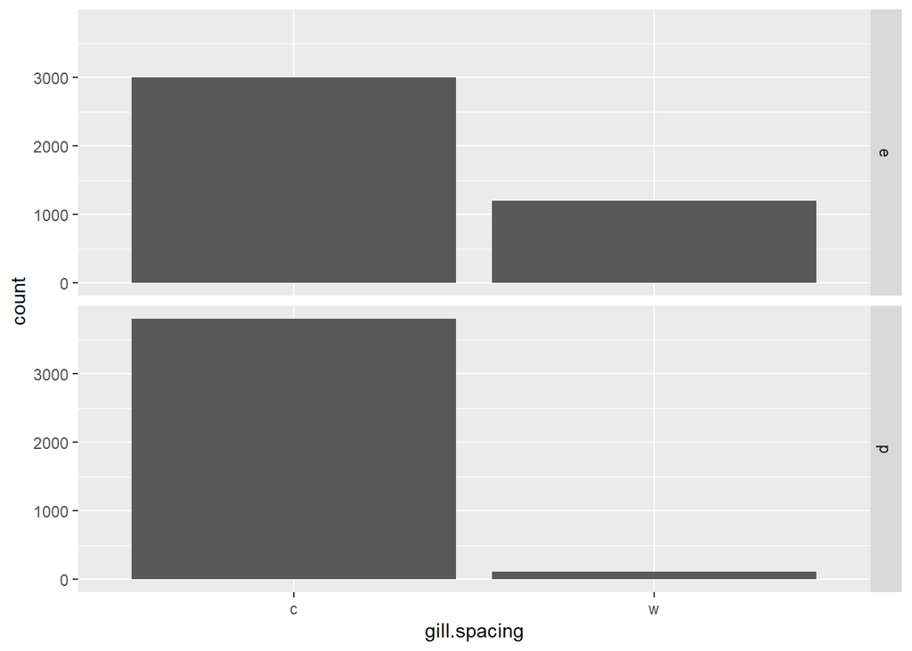

```r
ggplot(data, aes(x = gill.spacing)) + geom_histogram(stat = "count") + facet_grid(c("class"))
```

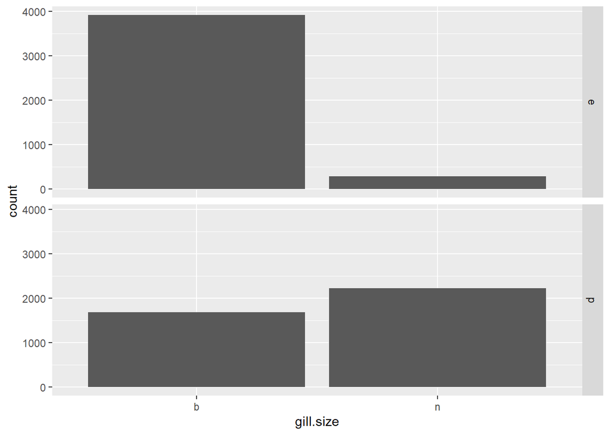

```r
ggplot(data, aes(x = gill.size)) + geom_histogram(stat = "count") + facet_grid(c("class"))
```

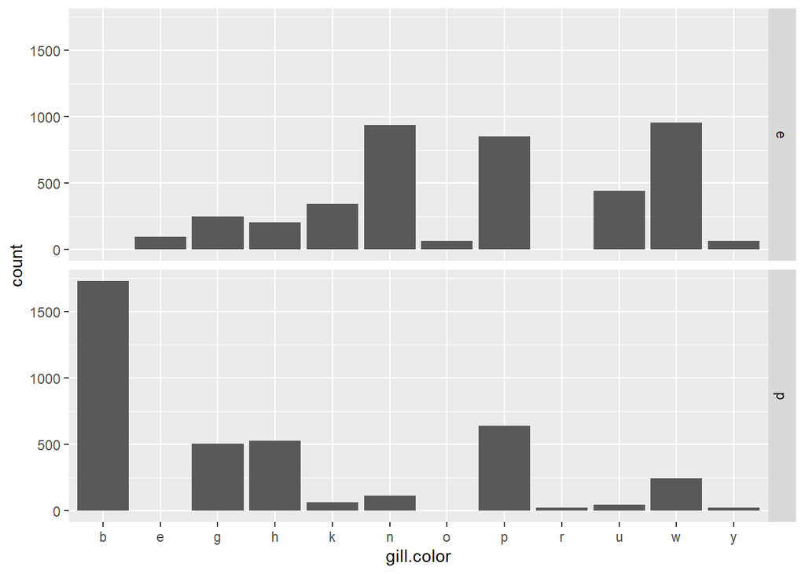

```r
ggplot(data, aes(x = gill.color)) + geom_histogram(stat = "count") + facet_grid(c("class"))
```

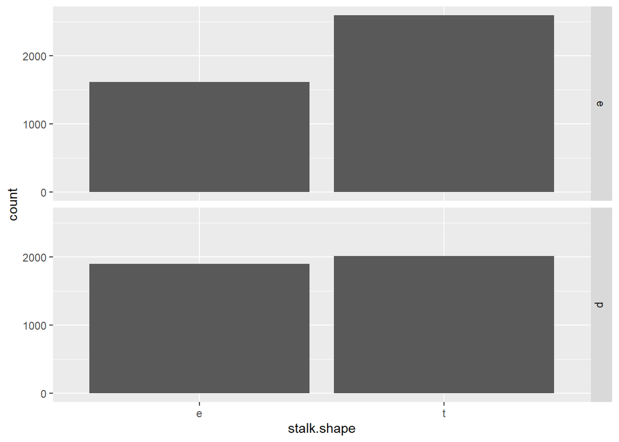

```r
ggplot(data, aes(x = stalk.shape)) + geom_histogram(stat = "count") + facet_grid(c("class"))
```

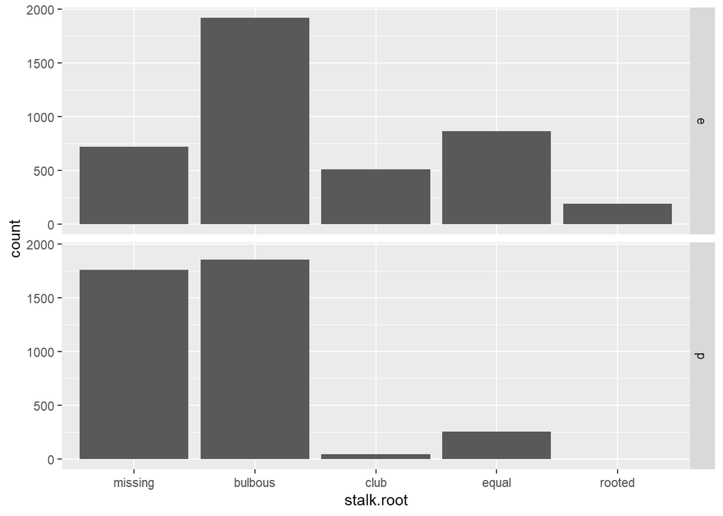

```r
ggplot(data, aes(x = stalk.root)) + geom_histogram(stat = "count") + facet_grid(c("class"))
```

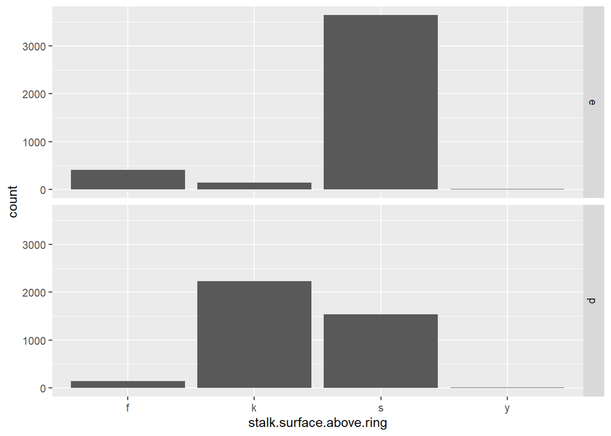

```r
ggplot(data, aes(x = stalk.surface.above.ring)) + geom_histogram(stat = "count") + facet_grid(c("class"))
```

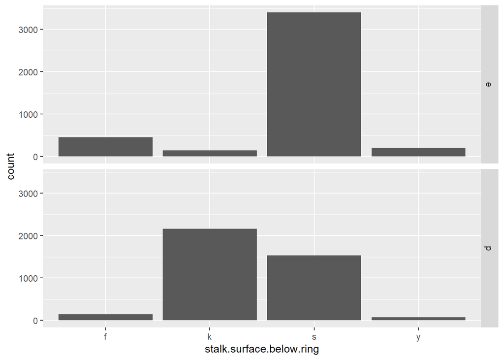

```r
ggplot(data, aes(x = stalk.surface.below.ring)) + geom_histogram(stat = "count") + facet_grid(c("class"))
```

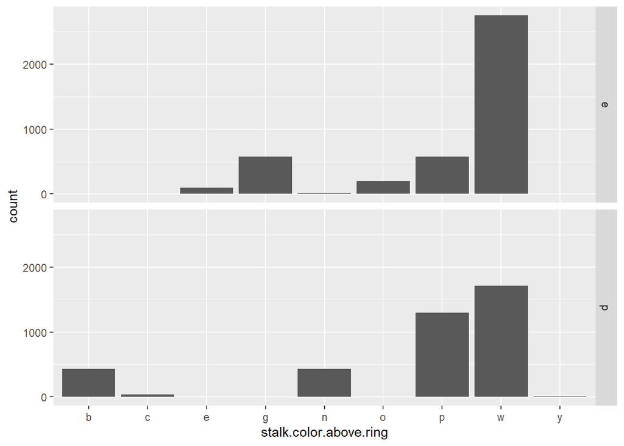

```r
ggplot(data, aes(x = stalk.color.above.ring)) + geom_histogram(stat = "count") + facet_grid(c("class"))
```

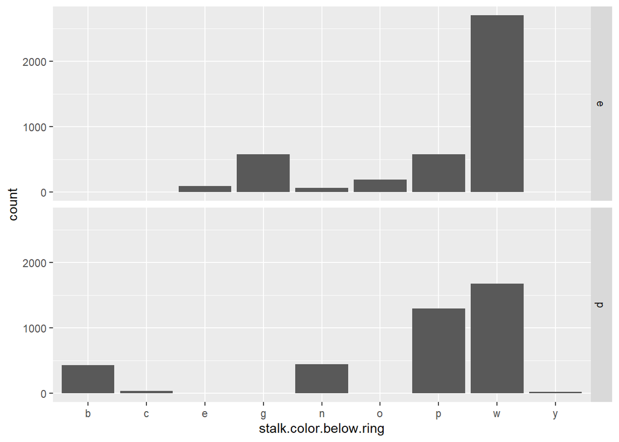

```r
ggplot(data, aes(x = stalk.color.below.ring)) + geom_histogram(stat = "count") + facet_grid(c("class"))
```

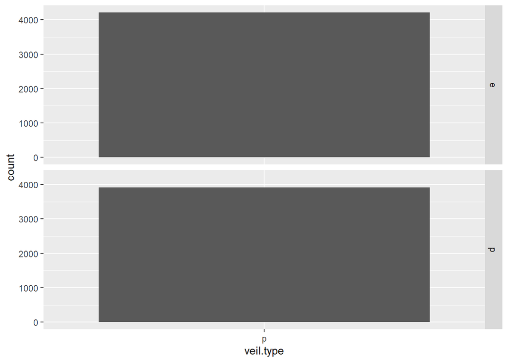

```r
ggplot(data, aes(x = veil.type)) + geom_histogram(stat = "count") + facet_grid(c("class"))
```

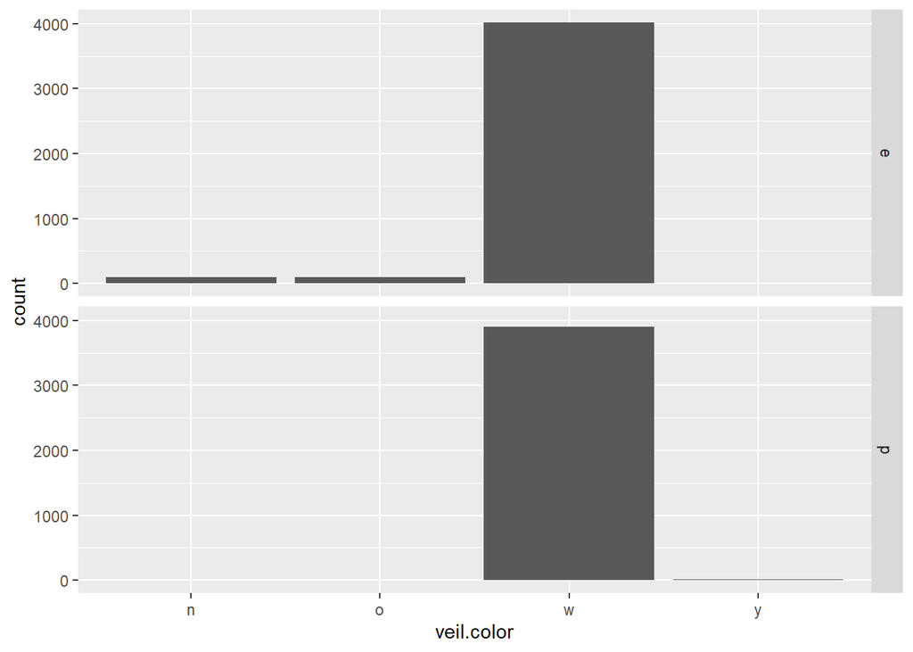

```r
ggplot(data, aes(x = veil.color)) + geom_histogram(stat = "count") + facet_grid(c("class"))
```

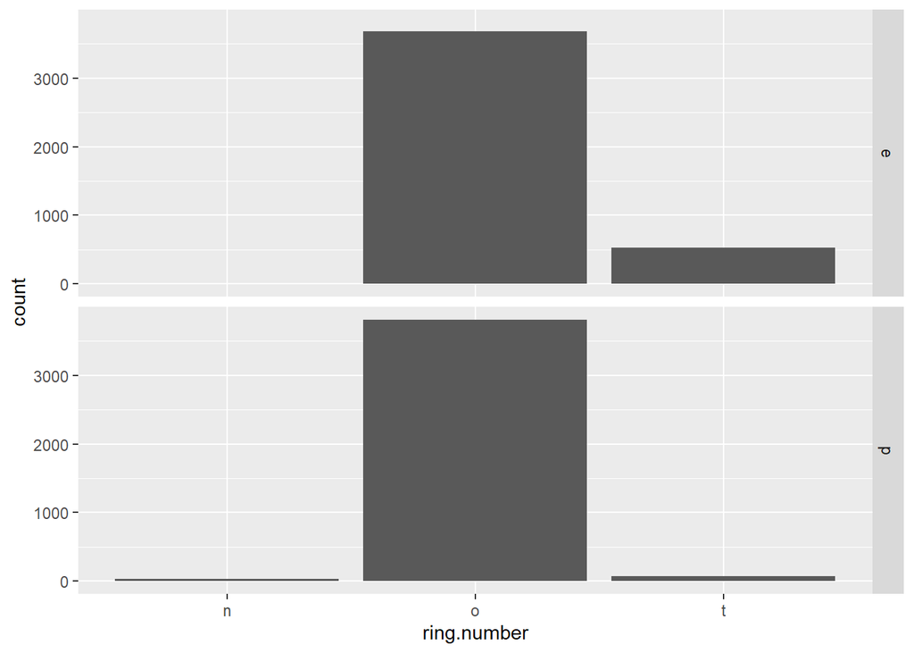

```r
ggplot(data, aes(x = ring.number)) + geom_histogram(stat = "count") + facet_grid(c("class"))
```

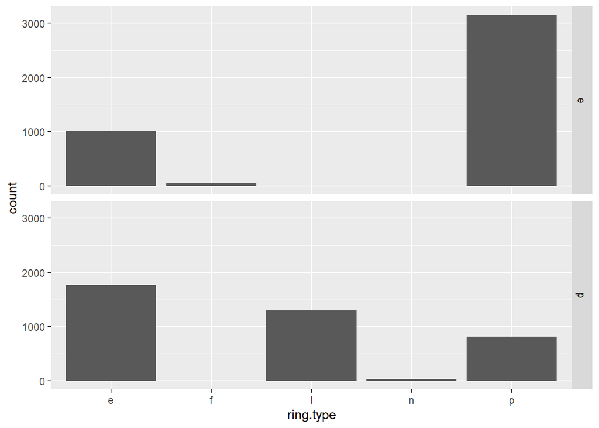

```r
ggplot(data, aes(x = ring.type)) + geom_histogram(stat = "count") + facet_grid(c("class"))
```

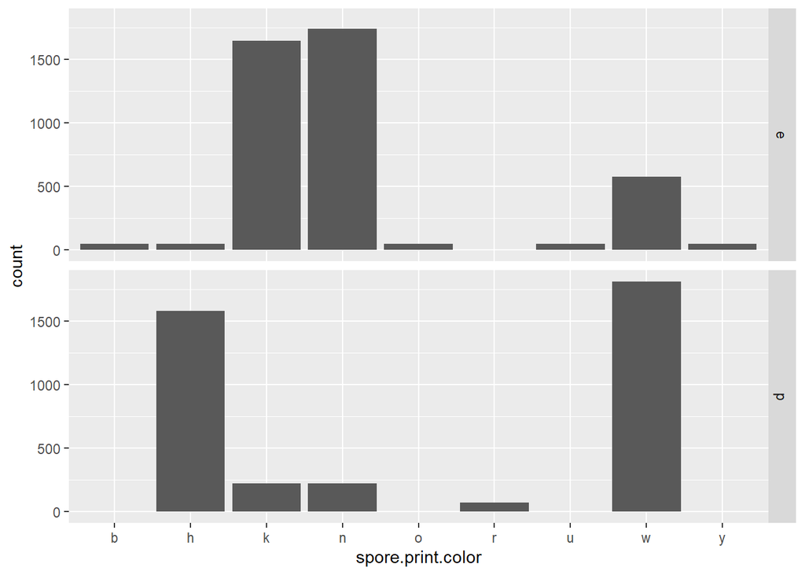

```r
ggplot(data, aes(x = spore.print.color)) + geom_histogram(stat = "count") + facet_grid(c("class"))
```

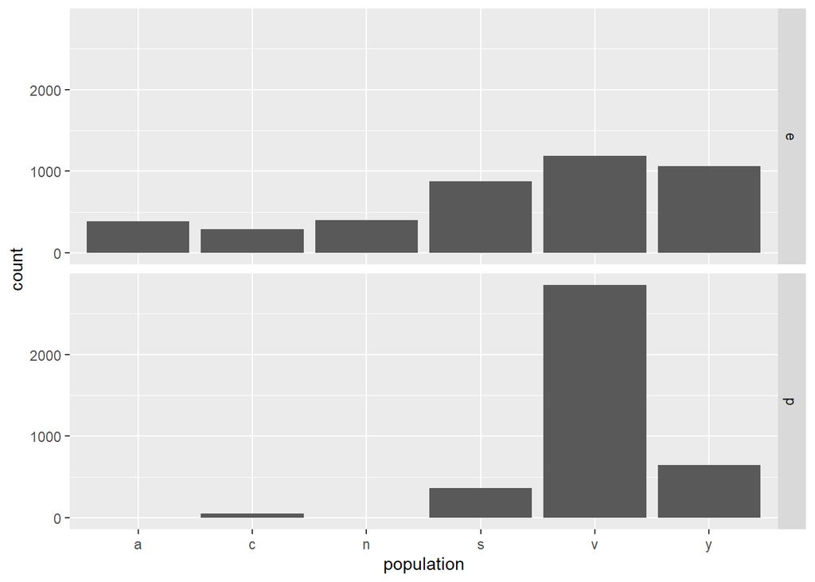

```r
ggplot(data, aes(x = population)) + geom_histogram(stat = "count") + facet_grid(c("class"))
```

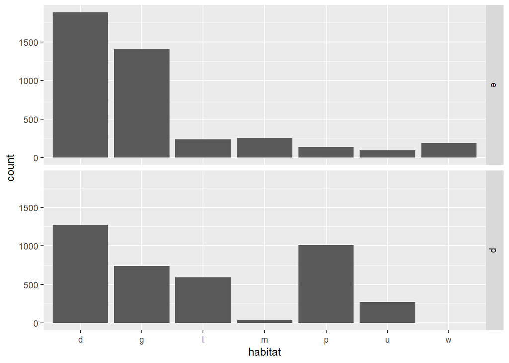

```r
ggplot(data, aes(x = habitat)) + geom_histogram(stat = "count") + facet_grid(c("class"))
```

4. Realice al menos 3 modelos vistos en clase

```r
# Crear los sets de entrenamiento y prueba
set.seed(23)
sample <- sample.split(data$class, SplitRatio = 0.7)
data.train <- data[sample,]
data.test <- data[!sample,]
```

```r
# Modelo de arbol de decision
tree <- rpart(class ~ ., data = data.train, method =  'class')
# Modelo de bosque aleatorio
forest <- randomForest(class ~ ., data = data.train)
# Modelo de Regresion logistica
regression <- glm(class ~ bruises + cap.color + odor + gill.spacing + gill.color + stalk.root + ring.type + spore.print.color, data = data.train, family = binomial)
```

5. Evaluación del modelo

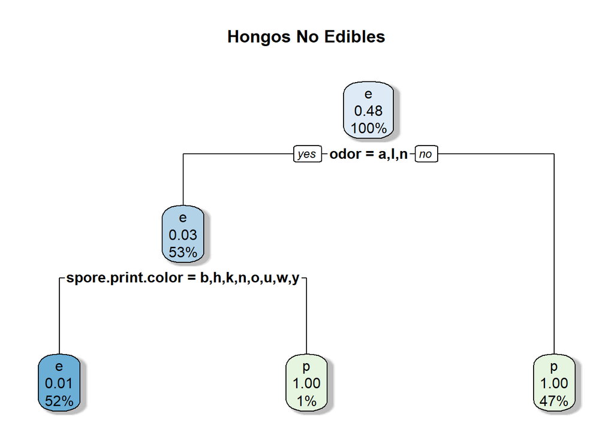

```r
# Modelo de Arbol de Decision
rpart.plot(tree, shadow.col = "gray", main = "Hongos No Edibles")
```

```r
tree.predict <- predict(tree, newdata = data.test, type = 'class')
table(data.test$class, tree.predict)
```

```
##    tree.predict
##        e    p
##   e 1262    0
##   p   12 1163
```

```r
# Modelo de Bosque Aleatorio
forest.predict <- predict(forest, newdata = data.test, type = 'class')
table(data.test$class, forest.predict)
```

```
##    forest.predict
##        e    p
##   e 1262    0
##   p    0 1175
```

```r
# Modelo de Regresion logistica
regression.predict <- predict(regression, newdata = data.test, type = 'response')
table(data.test$class, regression.predict >= 0.5)
```

```
##
##     FALSE TRUE
##   e  1262    0
##   p     0 1175
```

6. Desarolle al menos 3 conclusiones sobre las clasificaciones de los modelos
- El arbol de decision muestra que 1262 hongos se predijeron como edibles y lo eran, 1163 se predijeron como no edibles y no eran edibles, mientras que solo 12 se predijeron como edibles y no lo eran.
- El bosque aleatorio muestra que 1262 hongos se predijeron como edibles y lo eran; y 1175 se predijeron como no edibles y no lo eran, vale la pena destacar que es muy raro que tenga 100% de precision.
- El modelo de regresion logica muestra que 1262 hongos se predijeron como edibles y lo eran; y 1175 se predijeron como no edibles y no lo eran, vale la pena destacar que es muy raro que tenga 100% de precision.